# week-1

## MATH 189 • Data Analysis & Inference • Wi 2024

### Siddharth Vishwanath

$$ \long\def \forcecommand #1{\providecommand{#1}{}\renewcommand{#1}} \forcecommand{\defeq}{\stackrel{\small\bullet}{=}} \forcecommand{\ra}{\rangle} \forcecommand{\la}{\langle} \forcecommand{\pr}{{\mathbb P}} \forcecommand{\qr}{{\mathbb Q}} \forcecommand{\xv}{{\boldsymbol{x}}} \forcecommand{\av}{{\boldsymbol{a}}} \forcecommand{\bv}{{\boldsymbol{b}}} \forcecommand{\cv}{{\boldsymbol{c}}} \forcecommand{\dv}{{\boldsymbol{d}}} \forcecommand{\ev}{{\boldsymbol{e}}} \forcecommand{\fv}{{\boldsymbol{f}}} \forcecommand{\gv}{{\boldsymbol{g}}} \forcecommand{\hv}{{\boldsymbol{h}}} \forcecommand{\nv}{{\boldsymbol{n}}} \forcecommand{\sv}{{\boldsymbol{s}}} \forcecommand{\tv}{{\boldsymbol{t}}} \forcecommand{\uv}{{\boldsymbol{u}}} \forcecommand{\vv}{{\boldsymbol{v}}} \forcecommand{\wv}{{\boldsymbol{w}}} \forcecommand{\zerov}{{\mathbf{0}}} \forcecommand{\onev}{{\mathbf{0}}} \forcecommand{\phiv}{{\boldsymbol{\phi}}} \forcecommand{\cc}{{\check{C}}} % \forcecommand{\xv}{{\boldsymbol{x}}} \forcecommand{\Xv}{{\boldsymbol{X}\!}} \forcecommand{\yv}{{\boldsymbol{y}}} \forcecommand{\Yv}{{\boldsymbol{Y}}} \forcecommand{\zv}{{\boldsymbol{z}}} \forcecommand{\Zv}{{\boldsymbol{Z}}} \forcecommand{\Iv}{{\boldsymbol{I}}} \forcecommand{\Jv}{{\boldsymbol{J}}} \forcecommand{\Cv}{{\boldsymbol{C}}} \forcecommand{\Ev}{{\boldsymbol{E}}} \forcecommand{\Fv}{{\boldsymbol{F}}} \forcecommand{\Gv}{{\boldsymbol{G}}} \forcecommand{\Hv}{{\boldsymbol{H}}} \forcecommand{\alphav}{{\boldsymbol{\alpha}}} \forcecommand{\epsilonv}{{\boldsymbol{\epsilon}}} \forcecommand{\betav}{{\boldsymbol{\beta}}} \forcecommand{\deltav}{{\boldsymbol{\delta}}} \forcecommand{\gammav}{{\boldsymbol{\gamma}}} \forcecommand{\etav}{{\boldsymbol{\eta}}} \forcecommand{\piv}{{\boldsymbol{\pi}}} \forcecommand{\thetav}{{\boldsymbol{\theta}}} \forcecommand{\tauv}{{\boldsymbol{\tau}}} \forcecommand{\muv}{{\boldsymbol{\mu}}} % \forcecommand{\sd}{\text{SD}} \forcecommand{\se}{\text{SE}} \forcecommand{\med}{\text{median}} \forcecommand{\median}{\text{median}} % \forcecommand{\Ber}{{\text{Ber}}} \forcecommand{\Bin}{{\text{Bin}}} \forcecommand{\Geo}{{\text{Geo}}} \forcecommand{\Unif}{{\text{Unif}}} \forcecommand{\Poi}{{\text{Poi}}} \forcecommand{\Exp}{{\text{Exp}}} \forcecommand{\Chisq}{{\chi^2}} \forcecommand{\N}{\mathbb{N}} \forcecommand{\iid}{{\stackrel{iid}{\sim}}} \forcecommand{\px}{p_{X}} \forcecommand{\fx}{f_{X}} \forcecommand{\Fx}{F_{X}} \forcecommand{\py}{p_{Y}} \forcecommand{\pxy}{p_{X,Y}} \forcecommand{\po}{{p_0}} \forcecommand{\pa}{{p_a}} \forcecommand{\Xbar}{\overline{X}} \forcecommand{\Ybar}{\overline{Y}} \forcecommand{\Zbar}{\overline{Z}} \forcecommand{\nXbar}{n \cdot \overline{X}} \forcecommand{\nYbar}{n \cdot \overline{Y}} \forcecommand{\nZbar}{n \cdot \overline{Z}} \forcecommand{\Xn}{X_1, X_2, \dots, X_n} \forcecommand{\Xm}{{X_1, X_2, \dots, X_m}} \forcecommand{\Yn}{Y_1, Y_2, \dots, Y_n} \forcecommand{\Ym}{{Y_1, Y_2, \dots, Y_m}} \forcecommand{\sumXn}{X_1 + X_2 + \dots + X_n} \forcecommand{\sumym}{Y_1 + Y_2 + \dots + Y_m} \forcecommand{\la}{\ell_\alpha} \forcecommand{\ua}{u_\alpha} \forcecommand{\at}{{\alpha/2}} \forcecommand{\mux}{\mu_{X}} \forcecommand{\muy}{\mu_{Y}} \forcecommand{\sx}{\sigma_{X}} \forcecommand{\sy}{\sigma_{Y}} \forcecommand{\pvalue}{$p$-value} \forcecommand{\Ho}{H_{0}} \forcecommand{\Ha}{H_{a}} $$

## Agenda

# Basics of Markdown and $\LaTeX$

## §1.1: Creating sections for your document

THis is some text

This is more text

## §1.2: Bullet Lists and Numbered Lists

This is a numbered list:

1. This is numbered item 1
2. This is numbered item 2
3. This is numbered item 3

## §1.3: Math

### §1.3.1 Boxed & Colored Equations

$$ \newcommand{\Xnmean}{\frac{1}{n} \sum_{i=1}^n X_i} \boxed{\color{red}{\overline{X}} := \Xnmean } $$

### §1.3.2 Math Macros

$\Xnmean$

# §2. Basics of Python

## §2.1: Int, Float, Booleans, Strings

```python
type(1)
```

```
int
```

```python
type(1.0)
```

```
float
```

```python
type(True)
```

```
bool
```

```python
type('abcd')
```

```
str
```

#### §2.1.2 Arithmetic operations (+, -, *, /, %, //, **)

Arithmetic operations inherit the datatype of it's constituent elements, and based on the result.

```python
operations_int = [
    10 + 3,
    10 - 3,
    10 * 3,
    10 / 3,
    10 // 3,
    10 % 3,
    10 ** 3
]

[(x, type(x)) for x in operations_int]
```

```
[(13, int),
 (7, int),
 (30, int),
 (3.3333333333333335, float),
 (3, int),
 (1, int),
 (1000, int)]
```

```python
operations_float = [
    10.0 + 3,
    10.0 - 3,
    10.0 * 3,
    10.0 / 3,
    10.0 // 3,
    10.0 % 3,
    10.0 ** 3
]

[(x, type(x)) for x in operations_float]
```

```
[(13.0, float),
 (7.0, float),
 (30.0, float),
 (3.3333333333333335, float),
 (3.0, float),
 (1.0, float),
 (1000.0, float)]
```

## §2.2: Arrays, Tuples, Dicts

In Python, there are four main data structures that we will use:

1. Lists
2. Tuples
3. Sets
4. Dictionaries

##### §2.2.1: Lists

Lists are the most commonly used data structure in Python. They are mutable, and can be used to store any type of data. Lists are created using square brackets `[]` and elements are separated by commas.

```
x_list = [1, 2, 3, 4, 5]
```

Lists support indexing, slicing, and concatenation.

```
x_list[0] # returns 1
x_list[1:3] # returns [2, 3]
x_list + [6, 7, 8] # returns [1, 2, 3, 4, 5, 6, 7, 8]
x_list.append(10) # returns [1, 2, 3, 4, 5, 10] and stores the result in x_list
```

```python
x_list = [1, 2, 3, 4, 5]
type(x_list)
```

```
list
```

```python
x_list[0], x_list[1:3], x_list + [6, 7, 8]
```

```
(1, [2, 3], [1, 2, 3, 4, 5, 6, 7, 8])
```

```python
x_list.append(10)
x_list
```

```
[1, 2, 3, 4, 5, 10]
```

```python
x_list[0] = -1
x_list
```

```
[-1, 2, 3, 4, 5, 10]
```

##### §2.2.2: Tuples

Tuples are similar to lists, but are immutable. They are created using parentheses `()` and elements are separated by commas.

```
x_tuple = (1, 2, 3, 4, 5)
```

```python
x_tuple = (1, 2, 3, 4, 5)
type(x_tuple)
```

```
tuple
```

```python
x_tuple[0], x_tuple[1:3], x_tuple + (6, 7, 8)
```

```
(1, (2, 3), (1, 2, 3, 4, 5, 6, 7, 8))
```

```python
# this won't work
# x_tuple[0] = -1
```

##### §2.2.3: Sets

Sets are used to store unique elements. They are created using curly braces `{}` and elements are separated by commas.

```
x_set = {1, 2, 3, 4, 5}
```

Sets support set operations such as union, intersection, difference, and symmetric difference.

```
y_set = {4, 5, 6, 7, 8}
x_set | y_set # union
x_set & y_set # intersection
x_set - y_set # difference
x_set ^ y_set # symmetric difference
```

```python
x_set = {1, 2, 3, 4, 5}
type(x_set)
```

```
set
```

```python
y_set = {4, 5, 6, 7, 8}

x_set & y_set, x_set | y_set, x_set - y_set, x_set ^ y_set
```

```
({4, 5}, {1, 2, 3, 4, 5, 6, 7, 8}, {1, 2, 3}, {1, 2, 3, 6, 7, 8})
```

Recall that the symmetric difference of two sets $A$ and $B$ is defined as $A \Delta B = (A \cup B) \setminus (A \cap B)$.

Sets are also useful for removing duplicates from a list.

```
y_list = [1, 2, 3, 4, 5, 1, 2, 3]
set(y_list)
```

```python
y_list = [1, 2, 3, 4, 5, 1, 2, 3]
set(y_list)
```

```
{1, 2, 3, 4, 5}
```

##### §2.2.4: Dictionaries

Dictionaries are used to store key-value pairs. They are created using curly braces `{}` and elements are separated by commas. Each key-value pair is separated by a colon `:`.

```
x_dict = {'a': 1, 'b': 2, 'c': 3}
```

Dictionaries support indexing and updating values.

```
x_dict['a'] # returns 1
x_dict['d'] = 4 # adds a new key-value pair to the dictionary
x_dict['a'] = 10 # updates the value of the key 'a'
```

You can also make a dictionary from two lists using the `zip` function.

```
keys = ['a', 'b', 'c']
values = [1, 2, 3]
dict(zip(keys, values))
```

```python
x_dict = {"a": 1, "b":2, "c": 3}
type(x_dict)
```

```
dict
```

```python
x_dict['a']
x_dict['d'] = 4
x_dict['a'] = 10
x_dict
```

```
{'a': 10, 'b': 2, 'c': 3, 'd': 4}
```

## §2.3: Control Flow

There are three main control flow statements in Python: `if/elif/else`, `for`, and `while`.

##### §2.3.1: if/elif/else

The `if/elif/else` statement is used to check conditions and execute code based on the result of the condition. The `elif` and `else` statements are optional.

```
if condtion1:
    ... # do something
elif condition2:
    ... # do something
else:
    ... # do something
```

```python
x = -10
if x < 0:
    print('x is negative')
elif x == 0:
    print('x is zero')
else:
    print('x is positive')
```

```
x is negative
```

##### §2.3.2: `for` loops

The `for` loop is used to iterate over a sequence (list, tuple, set, dictionary, string, etc.) and execute code for each element in the sequence.

```
for element in sequence:
    ... # do something
```

```python
#################################################
# print(f'\n First for loop\n')
for i in range(5):
    print(i)

# #################################################
print(f'\n The iteration over a set happens in the reverse order\n')
x = {'a', 'b', 'c', 'd'}
for i in x:
    print(i)

# #################################################
print(f'\n By default a for loop over dict iterates over its keys\n')
x = {'a': 1, 'b': 2, 'c': 3, 'd': 4}
for i in x:
    print(i)

# #################################################
# # print(f'\n If you want to iterate over the key-value pair then you need to use x.items()\n')
x = {'a': 1, 'b': 2, 'c': 3, 'd': 4}
for i in x.items():
    print(i)
```

[output not shown]

## §2.4: Functions

Functions are defined using the `def` keyword. The `return` keyword is used to return a value from the function.

```
def my_function(arg1, arg2):
    ... # do something
    return result
```

```python
def fibonacci(n):
    if n == 0:
        return 0
    elif n == 1:
        return 1
    else:
        return fibonacci(n-1) + fibonacci(n-2)

fibonacci(10)
```

```
55
```

## §2.4.1: Anonymous Functions

Anonymous functions are defined using the `lambda` keyword. They are useful for defining simple functions in one line.

```
lambda arg1, arg2: operation(arg1, arg2)
```

```python
fib_2 = lambda n: 0 if n == 0 else 1 if n == 1 else fib_2(n-1) + fib_2(n-2)
fib_2(10)
```

```
55
```

# §3 Vectors and Linear Algebra

## §3.1 Numpy arrays and Matrices

The `numpy` package provides access to linear algebra routines in Python. You can install it using `pip install numpy` or `conda install numpy`. You can also install packages within a Jupyter notebook using the magic command `%pip install numpy`.

```python
%pip install numpy
```

```python
import numpy as np

x = np.array([1, 2, 3])
A = np.array([
    [1, 2, 3],
    [3, 4, 5],
    [10, 11, 12],
])

A @ x
```

```
array([14, 26, 68])
```

## §3.2: Linear Algebra on Vectors/Matrices

Operations on vectors and matrices:

1. If $x, y \in \R^d$ are two vectors, then $x + y$ is the vector whose $i$th element is $x_i + y_i$.

```python
# Vector addition
x = np.array([1, 2, 3])
y = np.array([-4, -5, -6])
x + y
```

```
array([-3, -3, -3])
```

2. If $x \in \R^d$ and $a \in \R$ is a scalar, then $a \cdot x$ is the vector whose $i$th element is $a \cdot x_i$.

```python
a = 10
a * x
```

```
array([10, 20, 30])
```

3. If $x, y \in \R^d$ are two vectors, then $x^T y$ is the dot product of $x$ and $y$.

```python
np.dot(x, y)
```

```
-32
```

4. If $x \in \R^d$ is a vector, then $\|x\|_2 = \sqrt{x^T x}$ is the Euclidean norm of $x$.

```python
np.linalg.norm(x)
```

```
3.7416573867739413
```

5. If $x \in \R^d$ is a vector, then $\|x\|_1 = \sum_{i=1}^d |x_i|$ is the $\ell_1$ norm of $x$.

```python
np.linalg.norm(x, 1)
```

```
6.0
```

6. If $x \in \R^d$ is a vector, then $\|x\|_\infty = \max_{i=1}^d |x_i|$ is the $\ell_\infty$ norm of $x$.

```python
np.linalg.norm(x, np.inf)
```

```
3.0
```

7. If $A$ is a $d \times d$ matrix, then $A^T$ is the transpose of $A$.

```python
# d = 3
A = np.array([[1, 2, 3], [4, 5, 6], [7, 8, 10]])

A, np.transpose(A), A.transpose()
```

```
(array([[ 1,  2,  3],
        [ 4,  5,  6],
        [ 7,  8, 10]]),
 array([[ 1,  4,  7],
        [ 2,  5,  8],
        [ 3,  6, 10]]),
 array([[ 1,  4,  7],
        [ 2,  5,  8],
        [ 3,  6, 10]]))
```

8. If $A$ is a $d \times d$ matrix, then $A^{-1}$ is the inverse of $A$.

```python
np.linalg.inv(A)
```

```
array([[-0.66666667, -1.33333333,  1.        ],
       [-0.66666667,  3.66666667, -2.        ],
       [ 1.        , -2.        ,  1.        ]])
```

9. If $A$ is a $d \times d$ matrix, then $\det(A)$ is the determinant of $A$.

```python
np.linalg.det(A)
```

```
-3.000000000000001
```

10. If $A$ is a $d \times d$ matrix, then $\text{tr}(A)$ is the trace of $A$.

```python
np.trace(A)
A.trace()
```

```
16
```

11. If $A$ is a $d \times d$ matrix, then $\lambda_1, \lambda_2, \dots, \lambda_d$ are the eigenvalues of $A$.

```python
eigenvalues, eigenvectors = np.linalg.eig(A)
eigenvalues
```

```
array([16.70749332, -0.90574018,  0.19824686])
```

13. If $x \in \R^d$ and $A$ is a $p \times d$ matrix, then $A x \in \R^p$ is the matrix-vector product of $A$ and $x$. The $i$th element of $A x$ is given by $(A x)_i = \sum_{j=1}^d A_{ij} x_j$.

```python
A.dot(x), np.dot(A, x), np.matmul(A, x), A @ x
```

```
(array([14, 32, 53]),
 array([14, 32, 53]),
 array([14, 32, 53]),
 array([14, 32, 53]))
```

14. If $A$ is a $p \times d$ matrix and $B$ is a $d \times q$ matrix, then $A B \in \R^{p \times q}$ is the matrix-matrix product of $A$ and $B$. The $(i, j)$th element of $A B$ is given by $(A B)_{ij} = \sum_{k=1}^d A_{ik} B_{kj}$.

```python
B = np.array([[1, 2], [3, 4]])
C = np.array([[5, 6], [7, 8]])

B @ C, B.dot(C), np.dot(B, C), np.matmul(B, C)
```

```
(array([[19, 22],
        [43, 50]]),
 array([[19, 22],
        [43, 50]]),
 array([[19, 22],
        [43, 50]]),
 array([[19, 22],
        [43, 50]]))
```

15. If $A$ is a $d \times d$ matrix, then the solution of $Ax = b$ is given by $x = A^{-1} b$.

```python
np.linalg.solve(B, np.array([1, 2]))
```

```
array([0. , 0.5])
```

```python
B @ np.array([0, 0.5])
```

```
array([1., 2.])
```

More functionality can be found [here](https://numpy.org/doc/stable/reference/routines.linalg.html)

## §3.2 Data Summarization

```python
(
    np.mean(x),
    np.std(x),
    np.var(x),
    np.median(x),
    np.quantile(x, 0.5),
    np.correlate(x, y)
)
```

```
(2.0, 0.816496580927726, 0.6666666666666666, 2.0, 2.0, array([-32]))
```

```python
(
    np.mean([1,2,3]),
    np.std([1,2,3]),
    np.var([1,2,3]),
    np.median([1,2,3]),
    np.quantile([1,2,3], 0.5),
    np.correlate([1,2,3], [4,5,6])
)
```

```
(2.0, 0.816496580927726, 0.6666666666666666, 2.0, 2.0, array([32]))
```

```python
(
    B,
    B.mean(axis=0), # Column wise
    B.mean(axis=1) # Row-wise
)
```

```
(array([[1, 2],
        [3, 4]]),
 array([2., 3.]),
 array([1.5, 3.5]))
```

## §3.4 What Python Knows in this session

```python
%who
```

```
A	 B	 C	 a	 eigenvalues	 eigenvectors	 fib_2	 fibonacci	 i
np	 operations_float	 operations_int	 x	 x_dict	 x_list	 x_set	 x_tuple	 y
y_list	 y_set
```

#### §3.4.1 Deleting variables from workspace

```python
del(C, a, eigenvectors)
%who
```

```
A	 B	 eigenvalues	 fib_2	 fibonacci	 i	 np	 operations_float	 operations_int
x	 x_dict	 x_list	 x_set	 x_tuple	 y	 y_list	 y_set
```

# §4. Data Manipulation

The main package for data manipulation in Python is `pandas`. It allows you to:

$$ \text{create } \longrightarrow \text{import } \longrightarrow \text{explore } \longrightarrow \text{modify } \longrightarrow \text{delete} $$

```python
import pandas as pd
```

##### §4.1: Create Data

```python
# create from a dictionary
data_dict = {
    'x': np.random.randint(0, 10, size=10),
    'y': np.random.choice(["a", "b"], size=10),
    'z_uniform': np.random.uniform(size=10),
    'z_normal': np.random.normal(size=10),
}
pd.DataFrame(data_dict)
```

|  | x | y | z_uniform | z_normal |
| --- | --- | --- | --- | --- |
| 0 | 0 | a | 0.157253 | 0.831635 |
| 1 | 7 | a | 0.709742 | 1.218363 |
| 2 | 5 | b | 0.996355 | -0.232266 |
| 3 | 5 | a | 0.078286 | 0.218692 |
| 4 | 3 | a | 0.362315 | 0.023916 |
| 5 | 6 | a | 0.898876 | 1.258546 |
| 6 | 4 | a | 0.921607 | 1.007562 |
| 7 | 7 | a | 0.584122 | -0.117295 |
| 8 | 1 | b | 0.269958 | 0.463928 |
| 9 | 7 | a | 0.560525 | 0.112526 |

```python
# create dataframe from a list (can even be a vanilla list)
data_list = np.array([
    np.random.randint(0, 10, size=5),
    np.random.choice(["a", "b", "c"], size=5),
    np.random.normal(size=5)
])

# pandas expects data to be in row-wise format, so we need to transpose
pd.DataFrame(data_list.transpose(), columns=['a', 'b', 'c'])
```

|  | a | b | c |
| --- | --- | --- | --- |
| 0 | 5 | c | 0.5702227907486611 |
| 1 | 7 | b | -1.5634299058797383 |
| 2 | 3 | c | -0.6130586977740281 |
| 3 | 9 | a | 1.5427622323046357 |
| 4 | 9 | b | -0.10122397491668343 |

##### §4.2: Import

You can import data from a CSV file using the `read_csv` function.

```
import pandas as pd
df = pd.read_csv('data.csv')
```

You can also read a data from a URL.

```python
url = 'https://gist.githubusercontent.com/netj/8836201/raw/6f9306ad21398ea43cba4f7d537619d0e07d5ae3/iris.csv'
df = pd.read_csv(url)
df
```

|  | sepal.length | sepal.width | petal.length | petal.width | variety |
| --- | --- | --- | --- | --- | --- |
| 0 | 5.1 | 3.5 | 1.4 | 0.2 | Setosa |
| 1 | 4.9 | 3.0 | 1.4 | 0.2 | Setosa |
| 2 | 4.7 | 3.2 | 1.3 | 0.2 | Setosa |
| 3 | 4.6 | 3.1 | 1.5 | 0.2 | Setosa |
| 4 | 5.0 | 3.6 | 1.4 | 0.2 | Setosa |
| ... | ... | ... | ... | ... | ... |
| 145 | 6.7 | 3.0 | 5.2 | 2.3 | Virginica |
| 146 | 6.3 | 2.5 | 5.0 | 1.9 | Virginica |
| 147 | 6.5 | 3.0 | 5.2 | 2.0 | Virginica |
| 148 | 6.2 | 3.4 | 5.4 | 2.3 | Virginica |
| 149 | 5.9 | 3.0 | 5.1 | 1.8 | Virginica |

150 rows × 5 columns

```python
df2 = pd.DataFrame(data_dict)
```

##### §4.3: Explore

```python
# display the first 10 rows

df.head(10)
```

|  | sepal.length | sepal.width | petal.length | petal.width | variety |
| --- | --- | --- | --- | --- | --- |
| 0 | 5.1 | 3.5 | 1.4 | 0.2 | Setosa |
| 1 | 4.9 | 3.0 | 1.4 | 0.2 | Setosa |
| 2 | 4.7 | 3.2 | 1.3 | 0.2 | Setosa |
| 3 | 4.6 | 3.1 | 1.5 | 0.2 | Setosa |
| 4 | 5.0 | 3.6 | 1.4 | 0.2 | Setosa |
| 5 | 5.4 | 3.9 | 1.7 | 0.4 | Setosa |
| 6 | 4.6 | 3.4 | 1.4 | 0.3 | Setosa |
| 7 | 5.0 | 3.4 | 1.5 | 0.2 | Setosa |
| 8 | 4.4 | 2.9 | 1.4 | 0.2 | Setosa |
| 9 | 4.9 | 3.1 | 1.5 | 0.1 | Setosa |

```python
# or display the last 10 rows

df.tail(10)
```

|  | sepal.length | sepal.width | petal.length | petal.width | variety |
| --- | --- | --- | --- | --- | --- |
| 140 | 6.7 | 3.1 | 5.6 | 2.4 | Virginica |
| 141 | 6.9 | 3.1 | 5.1 | 2.3 | Virginica |
| 142 | 5.8 | 2.7 | 5.1 | 1.9 | Virginica |
| 143 | 6.8 | 3.2 | 5.9 | 2.3 | Virginica |
| 144 | 6.7 | 3.3 | 5.7 | 2.5 | Virginica |
| 145 | 6.7 | 3.0 | 5.2 | 2.3 | Virginica |
| 146 | 6.3 | 2.5 | 5.0 | 1.9 | Virginica |
| 147 | 6.5 | 3.0 | 5.2 | 2.0 | Virginica |
| 148 | 6.2 | 3.4 | 5.4 | 2.3 | Virginica |
| 149 | 5.9 | 3.0 | 5.1 | 1.8 | Virginica |

##### §4.3.1: Data Types

```python
df.dtypes
```

```
sepal.length    float64
sepal.width     float64
petal.length    float64
petal.width     float64
variety          object
dtype: object
```

```python
df2.dtypes
```

```
x              int64
y             object
z_uniform    float64
z_normal     float64
dtype: object
```

##### §4.3.2: Summary Statistics

```python
df.describe()
```

|  | sepal.length | sepal.width | petal.length | petal.width |
| --- | --- | --- | --- | --- |
| count | 150.000000 | 150.000000 | 150.000000 | 150.000000 |
| mean | 5.843333 | 3.057333 | 3.758000 | 1.199333 |
| std | 0.828066 | 0.435866 | 1.765298 | 0.762238 |
| min | 4.300000 | 2.000000 | 1.000000 | 0.100000 |
| 25% | 5.100000 | 2.800000 | 1.600000 | 0.300000 |
| 50% | 5.800000 | 3.000000 | 4.350000 | 1.300000 |
| 75% | 6.400000 | 3.300000 | 5.100000 | 1.800000 |
| max | 7.900000 | 4.400000 | 6.900000 | 2.500000 |

```python
df2.describe()
```

|  | x | z_uniform | z_normal |
| --- | --- | --- | --- |
| count | 10.000000 | 10.000000 | 10.000000 |
| mean | 4.500000 | 0.553904 | 0.478561 |
| std | 2.505549 | 0.329325 | 0.560648 |
| min | 0.000000 | 0.078286 | -0.232266 |
| 25% | 3.250000 | 0.293047 | 0.046068 |
| 50% | 5.000000 | 0.572323 | 0.341310 |
| 75% | 6.750000 | 0.851593 | 0.963580 |
| max | 7.000000 | 0.996355 | 1.258546 |

##### §4.3.3: Subsetting Columns

```python
df.columns
```

```
Index(['sepal.length', 'sepal.width', 'petal.length', 'petal.width',
       'variety'],
      dtype='object')
```

```python
# This works
df.variety
```

```
0         Setosa
1         Setosa
2         Setosa
3         Setosa
4         Setosa
         ...
145    Virginica
146    Virginica
147    Virginica
148    Virginica
149    Virginica
Name: variety, Length: 150, dtype: object
```

```python
# This doesn't work
# df.sepal.length
```

```python
df['sepal.length']
```

```
0      5.1
1      4.9
2      4.7
3      4.6
4      5.0
      ...
145    6.7
146    6.3
147    6.5
148    6.2
149    5.9
Name: sepal.length, Length: 150, dtype: float64
```

```python
df[['sepal.length', 'variety']]
```

|  | sepal.length | variety |
| --- | --- | --- |
| 0 | 5.1 | Setosa |
| 1 | 4.9 | Setosa |
| 2 | 4.7 | Setosa |
| 3 | 4.6 | Setosa |
| 4 | 5.0 | Setosa |
| ... | ... | ... |
| 145 | 6.7 | Virginica |
| 146 | 6.3 | Virginica |
| 147 | 6.5 | Virginica |
| 148 | 6.2 | Virginica |
| 149 | 5.9 | Virginica |

150 rows × 2 columns

You can (and, should) use `df.loc` and `df.iloc`.

```
* `df.loc` uses labels to subset columns/rows, whereas
* `df.iloc` uses indices to subset columns/rows.
```

```python
df.loc[:, ['sepal.length', 'variety']]
```

|  | sepal.length | variety |
| --- | --- | --- |
| 0 | 5.1 | Setosa |
| 1 | 4.9 | Setosa |
| 2 | 4.7 | Setosa |
| 3 | 4.6 | Setosa |
| 4 | 5.0 | Setosa |
| ... | ... | ... |
| 145 | 6.7 | Virginica |
| 146 | 6.3 | Virginica |
| 147 | 6.5 | Virginica |
| 148 | 6.2 | Virginica |
| 149 | 5.9 | Virginica |

150 rows × 2 columns

```python
df.iloc[:, [0, 4]]
```

|  | sepal.length | variety |
| --- | --- | --- |
| 0 | 5.1 | Setosa |
| 1 | 4.9 | Setosa |
| 2 | 4.7 | Setosa |
| 3 | 4.6 | Setosa |
| 4 | 5.0 | Setosa |
| ... | ... | ... |
| 145 | 6.7 | Virginica |
| 146 | 6.3 | Virginica |
| 147 | 6.5 | Virginica |
| 148 | 6.2 | Virginica |
| 149 | 5.9 | Virginica |

150 rows × 2 columns

##### §4.3.4: Subsetting Rows

Find all rows corresponding to the type 'Versicolor'.

```python
df[df['variety'] == 'Versicolor']\
    .head(10)
```

|  | sepal.length | sepal.width | petal.length | petal.width | variety |
| --- | --- | --- | --- | --- | --- |
| 50 | 7.0 | 3.2 | 4.7 | 1.4 | Versicolor |
| 51 | 6.4 | 3.2 | 4.5 | 1.5 | Versicolor |
| 52 | 6.9 | 3.1 | 4.9 | 1.5 | Versicolor |
| 53 | 5.5 | 2.3 | 4.0 | 1.3 | Versicolor |
| 54 | 6.5 | 2.8 | 4.6 | 1.5 | Versicolor |
| 55 | 5.7 | 2.8 | 4.5 | 1.3 | Versicolor |
| 56 | 6.3 | 3.3 | 4.7 | 1.6 | Versicolor |
| 57 | 4.9 | 2.4 | 3.3 | 1.0 | Versicolor |
| 58 | 6.6 | 2.9 | 4.6 | 1.3 | Versicolor |
| 59 | 5.2 | 2.7 | 3.9 | 1.4 | Versicolor |

Find all rows where sepal.length > 5

```python
df[df.iloc[:, 0] > 5]\
    .head(10)
```

|  | sepal.length | sepal.width | petal.length | petal.width | variety |
| --- | --- | --- | --- | --- | --- |
| 0 | 5.1 | 3.5 | 1.4 | 0.2 | Setosa |
| 5 | 5.4 | 3.9 | 1.7 | 0.4 | Setosa |
| 10 | 5.4 | 3.7 | 1.5 | 0.2 | Setosa |
| 14 | 5.8 | 4.0 | 1.2 | 0.2 | Setosa |
| 15 | 5.7 | 4.4 | 1.5 | 0.4 | Setosa |
| 16 | 5.4 | 3.9 | 1.3 | 0.4 | Setosa |
| 17 | 5.1 | 3.5 | 1.4 | 0.3 | Setosa |
| 18 | 5.7 | 3.8 | 1.7 | 0.3 | Setosa |
| 19 | 5.1 | 3.8 | 1.5 | 0.3 | Setosa |
| 20 | 5.4 | 3.4 | 1.7 | 0.2 | Setosa |

##### §4.4: Modify Data

Add a new column called 'sepal.area' to the dataframe.

```python
df['sepal.area'] = df['sepal.length'] * df['sepal.width']
df.head(10)
```

|  | sepal.length | sepal.width | petal.length | petal.width | variety | sepal.area |
| --- | --- | --- | --- | --- | --- | --- |
| 0 | 5.1 | 3.5 | 1.4 | 0.2 | Setosa | 17.85 |
| 1 | 4.9 | 3.0 | 1.4 | 0.2 | Setosa | 14.70 |
| 2 | 4.7 | 3.2 | 1.3 | 0.2 | Setosa | 15.04 |
| 3 | 4.6 | 3.1 | 1.5 | 0.2 | Setosa | 14.26 |
| 4 | 5.0 | 3.6 | 1.4 | 0.2 | Setosa | 18.00 |
| 5 | 5.4 | 3.9 | 1.7 | 0.4 | Setosa | 21.06 |
| 6 | 4.6 | 3.4 | 1.4 | 0.3 | Setosa | 15.64 |
| 7 | 5.0 | 3.4 | 1.5 | 0.2 | Setosa | 17.00 |
| 8 | 4.4 | 2.9 | 1.4 | 0.2 | Setosa | 12.76 |
| 9 | 4.9 | 3.1 | 1.5 | 0.1 | Setosa | 15.19 |

Add a new column called 'virginica.variety' to the dataframe which takes a value of 1 if the variety is 'Virginica' and 0 otherwise.

```python
df['virginica.variety']  = df['variety'] == 'Virginica'
df.iloc[[0, 1, 2, -100, -2, -1], :]
```

|  | sepal.length | sepal.width | petal.length | petal.width | variety | sepal.area | virginica.variety |
| --- | --- | --- | --- | --- | --- | --- | --- |
| 0 | 5.1 | 3.5 | 1.4 | 0.2 | Setosa | 17.85 | False |
| 1 | 4.9 | 3.0 | 1.4 | 0.2 | Setosa | 14.70 | False |
| 2 | 4.7 | 3.2 | 1.3 | 0.2 | Setosa | 15.04 | False |
| 50 | 7.0 | 3.2 | 4.7 | 1.4 | Versicolor | 22.40 | False |
| 148 | 6.2 | 3.4 | 5.4 | 2.3 | Virginica | 21.08 | True |
| 149 | 5.9 | 3.0 | 5.1 | 1.8 | Virginica | 17.70 | True |

Similarly

```python
df['setosa.variety']  = df.apply(lambda row: row['variety'] == 'Setosa', axis=1)
df.iloc[[0, 1, 2, -100, -2, -1], :]
```

|  | sepal.length | sepal.width | petal.length | petal.width | variety | sepal.area | virginica.variety | setosa.variety |
| --- | --- | --- | --- | --- | --- | --- | --- | --- |
| 0 | 5.1 | 3.5 | 1.4 | 0.2 | Setosa | 17.85 | False | True |
| 1 | 4.9 | 3.0 | 1.4 | 0.2 | Setosa | 14.70 | False | True |
| 2 | 4.7 | 3.2 | 1.3 | 0.2 | Setosa | 15.04 | False | True |
| 50 | 7.0 | 3.2 | 4.7 | 1.4 | Versicolor | 22.40 | False | False |
| 148 | 6.2 | 3.4 | 5.4 | 2.3 | Virginica | 21.08 | True | False |
| 149 | 5.9 | 3.0 | 5.1 | 1.8 | Virginica | 17.70 | True | False |

##### §4.5: Delete

```python
df.drop(columns = ['sepal.length', 'petal.length'])
```

|  | sepal.width | petal.width | variety | sepal.area | virginica.variety | setosa.variety |
| --- | --- | --- | --- | --- | --- | --- |
| 0 | 3.5 | 0.2 | Setosa | 17.85 | False | True |
| 1 | 3.0 | 0.2 | Setosa | 14.70 | False | True |
| 2 | 3.2 | 0.2 | Setosa | 15.04 | False | True |
| 3 | 3.1 | 0.2 | Setosa | 14.26 | False | True |
| 4 | 3.6 | 0.2 | Setosa | 18.00 | False | True |
| ... | ... | ... | ... | ... | ... | ... |
| 145 | 3.0 | 2.3 | Virginica | 20.10 | True | False |
| 146 | 2.5 | 1.9 | Virginica | 15.75 | True | False |
| 147 | 3.0 | 2.0 | Virginica | 19.50 | True | False |
| 148 | 3.4 | 2.3 | Virginica | 21.08 | True | False |
| 149 | 3.0 | 1.8 | Virginica | 17.70 | True | False |

150 rows × 6 columns

```python
df.drop([0, 1]) # drops rows
```

|  | sepal.length | sepal.width | petal.length | petal.width | variety | sepal.area | virginica.variety | setosa.variety |
| --- | --- | --- | --- | --- | --- | --- | --- | --- |
| 2 | 4.7 | 3.2 | 1.3 | 0.2 | Setosa | 15.04 | False | True |
| 3 | 4.6 | 3.1 | 1.5 | 0.2 | Setosa | 14.26 | False | True |
| 4 | 5.0 | 3.6 | 1.4 | 0.2 | Setosa | 18.00 | False | True |
| 5 | 5.4 | 3.9 | 1.7 | 0.4 | Setosa | 21.06 | False | True |
| 6 | 4.6 | 3.4 | 1.4 | 0.3 | Setosa | 15.64 | False | True |
| ... | ... | ... | ... | ... | ... | ... | ... | ... |
| 145 | 6.7 | 3.0 | 5.2 | 2.3 | Virginica | 20.10 | True | False |
| 146 | 6.3 | 2.5 | 5.0 | 1.9 | Virginica | 15.75 | True | False |
| 147 | 6.5 | 3.0 | 5.2 | 2.0 | Virginica | 19.50 | True | False |
| 148 | 6.2 | 3.4 | 5.4 | 2.3 | Virginica | 21.08 | True | False |
| 149 | 5.9 | 3.0 | 5.1 | 1.8 | Virginica | 17.70 | True | False |

148 rows × 8 columns

```python
del(df['setosa.variety'])
df
```

|  | sepal.length | sepal.width | petal.length | petal.width | variety | sepal.area | virginica.variety |
| --- | --- | --- | --- | --- | --- | --- | --- |
| 0 | 5.1 | 3.5 | 1.4 | 0.2 | Setosa | 17.85 | False |
| 1 | 4.9 | 3.0 | 1.4 | 0.2 | Setosa | 14.70 | False |
| 2 | 4.7 | 3.2 | 1.3 | 0.2 | Setosa | 15.04 | False |
| 3 | 4.6 | 3.1 | 1.5 | 0.2 | Setosa | 14.26 | False |
| 4 | 5.0 | 3.6 | 1.4 | 0.2 | Setosa | 18.00 | False |
| ... | ... | ... | ... | ... | ... | ... | ... |
| 145 | 6.7 | 3.0 | 5.2 | 2.3 | Virginica | 20.10 | True |
| 146 | 6.3 | 2.5 | 5.0 | 1.9 | Virginica | 15.75 | True |
| 147 | 6.5 | 3.0 | 5.2 | 2.0 | Virginica | 19.50 | True |
| 148 | 6.2 | 3.4 | 5.4 | 2.3 | Virginica | 21.08 | True |
| 149 | 5.9 | 3.0 | 5.1 | 1.8 | Virginica | 17.70 | True |

150 rows × 7 columns

```python
df.to_csv('iris_modified.csv', index=False)
```

---

# §5. Data Visualization

There are several packages for data visualization in Python. The main ones I'd like you to familiarize yourself with are: `matplotlib`, `seaborn` and `gr`

`%pip install matplotlib seaborn gr`

### Line Plots

```python
x=np.linspace(-10, 10, 1000)
```

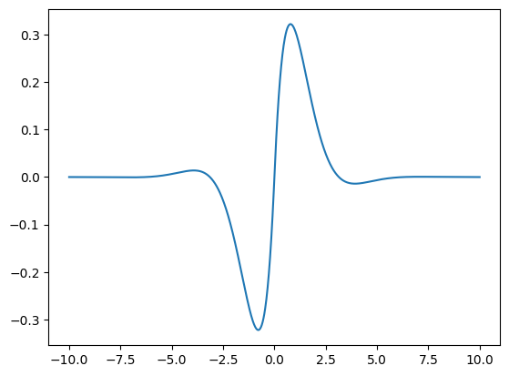

```python
%matplotlib inline
from matplotlib import pyplot as plt
plt.plot(x, np.sin(x) * np.exp(-np.abs(x)), label='x^2')
```

```python
from gr import pygr
pygr.plot(x, lambda x: np.sin(x) * np.exp(-np.abs(x)), label='x^2')
```

[figure not shown]

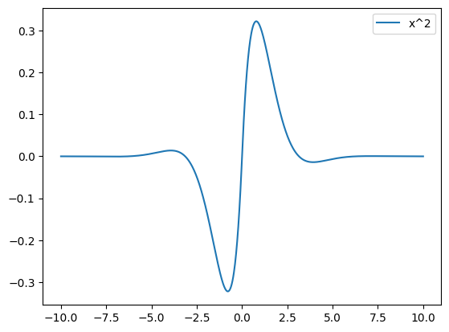

```python
import seaborn as sns
sns.lineplot(x=x, y=np.sin(x) * np.exp(-np.abs(x)), label='x^2')
```

### §5.1: Bar Charts

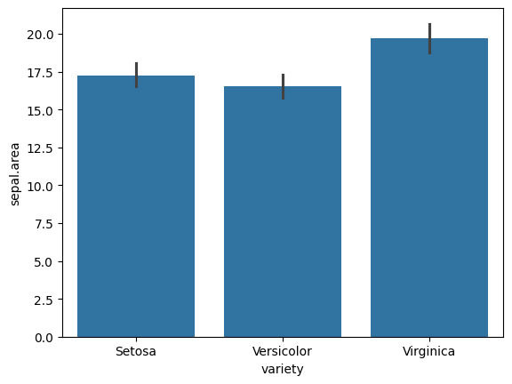

```python
sns.barplot(df, x = 'variety', y='sepal.area')
```

### §5.2: Histograms

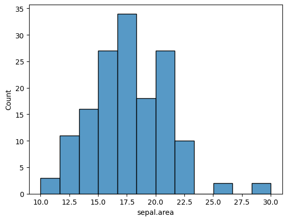

```python
sns.histplot(df, x = 'sepal.area')
```

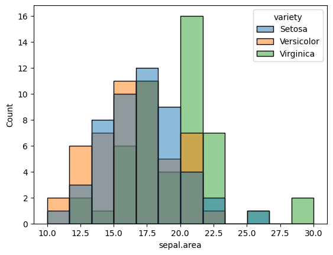

```python
sns.histplot(df, x = 'sepal.area', hue='variety')
```

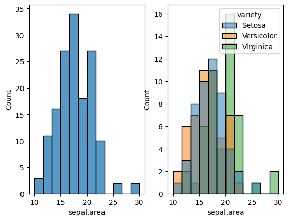

```python
fig, ax = plt.subplots(ncols=2)
sns.histplot(df, x = 'sepal.area', ax=ax[0])
sns.histplot(df, x = 'sepal.area', hue='variety', ax=ax[1])
```

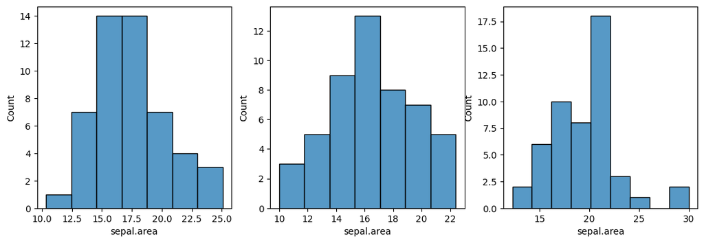

```python
fix, axes = plt.subplots(ncols=3, figsize=(13, 4))
for i, variety in enumerate(df['variety'].unique()):
    sns.histplot(df[df['variety'] == variety], x = 'sepal.area', ax=axes[i])
```

### §5.4: Box Plots

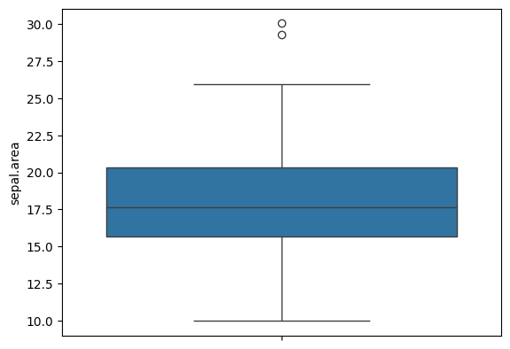

```python
sns.boxplot(df, y = 'sepal.area')
```

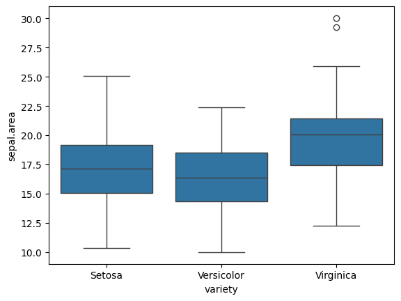

```python
sns.boxplot(df, x='variety', y = 'sepal.area')
```

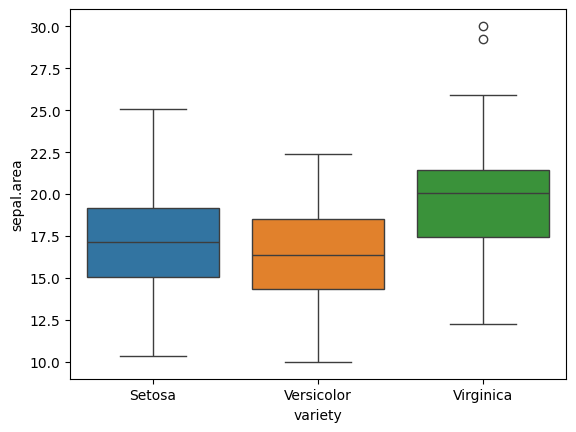

```python
sns.boxplot(df, x='variety', y = 'sepal.area', hue='variety')
```

### §5.3: Scatter Plots

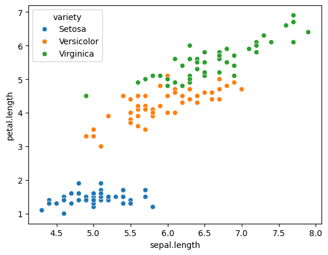

```python
sns.scatterplot(df, x='sepal.length', y = 'petal.length', hue='variety')
```

### §5.5: Heat Maps

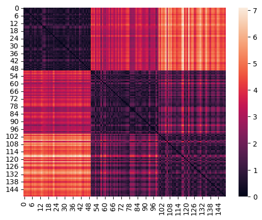

```python
from scipy.spatial import distance_matrix

quantitative_columns = np.array(df.iloc[:, 0:4])
D = distance_matrix(quantitative_columns, quantitative_columns)

sns.heatmap(D)
```